# ST758 2014 HW4

Hua Zhou

Oct 2, 2014

# Q1

Let $\boldsymbol{A} = (a_{ij}) \in \{0,1\}^{n \times n}$ be the connectivity matrix with entries  
$a_{ij} = \begin{cases} 1 & \text{if page $i$ links to page $j$} \\ 0 & \text{otherwise} \end{cases}.$ Let $\boldsymbol{r} = (r_1, \ldots, r_n)^T$ be the out-degree vector with entries $r_i = \sum_j a_{ij}$. $p$ is the teleportation parameter usually set at 0.85. The transition probability from page $i$ to page $j$ is $p_{ij} = \begin{cases} p a_{ij} / r_i + (1-p) / n & r_i > 0 \\ 1/n & r_i = 0 \end{cases}.$ In matrix-vector notation, we write $\boldsymbol{P} = \text{diag}(\boldsymbol{r}^+) \boldsymbol{A} + \boldsymbol{z} \boldsymbol{1}_n^T,$ where $\boldsymbol{r}^+ \in \mathbb{R}^n$ has entries $r_i^+ = \begin{cases} p/r_i & r_i > 0 \\ 0 & r_i = 0 \end{cases}$ and $\boldsymbol{z} \in \mathbb{R}^n$ has entries $z_i = \begin{cases} (1-p)/n & r_i > 0 \\ 1/n & r_i = 0 \end{cases}.$ We recognize the “sparse + low rank” structure in $\boldsymbol{P}$ and want to take advantage of it in computing. Indeed $\boldsymbol{A}$ is not only sparse, all its nonzero entries are 1. In `Matlab`, I would save it as a sparse logical array, which saves tremendous amount of memory and computation. However I didn’t find similar capability in `R`.

# Q2

Since this Markov chain is irreducible (we can reach page $j$ from page $i$ for any $i$ and $j$), there exists a unique stationary distribution $\boldsymbol{x} \in \mathbb{R}^n$, which is the left eigenvector of the transition matrix corresponding to eigenvalue 1. That is $\boldsymbol{P}^T \boldsymbol{x} = \boldsymbol{x}$. Equivalently $\boldsymbol{x}$ is a solution to the linear system $(\boldsymbol{I}_n - \boldsymbol{P}^T) \boldsymbol{x} = \boldsymbol{0}_n.$ Note the column sums of the matrix $\boldsymbol{I}_n - \boldsymbol{P}^T$ are all 0s, implying singularity. One equation is redundant. We replace the first one with the constraint equation $\boldsymbol{1}_n^T \boldsymbol{x} = 1$, when calling `lu` function.

# Q3

Let’s start with some descriptive statistics of the `stat-ncsu` data. I found counting or ignoring self-links make a big difference in rankings. Results presented below count self-links.

```r
# download, unzip, and read in data
if (!file.exists("stat-ncsu.zip")) {
  download.file("http://hua-zhou.github.io/teaching/st758-2014fall/stat-ncsu.zip",
                destfile = "stat-ncsu.zip")
  }
A <- read.table(unz("stat-ncsu.zip", "A.txt"), sep = ",")
A <- as.matrix(t(A))
U <- read.table(unz("stat-ncsu.zip", "U.txt"))
U <- as.matrix(U)

# # remove self-links
# n <- dim(A)[1]
# diag(A) <- 0

# how many pages?
dim(A)[1]
```

```
## [1] 500
```

```r
# how many edges (page links)?
sum(A)
```

```
## [1] 19200
```

```r
# how many dangling nodes (pages with no out links)?
outdeg <- rowSums(A)
sum(outdeg < 1)
```

```
## [1] 82
```

```r
# which page has max in-degree?
indeg <- colSums(A)
idxideg <- which.max(indeg)
U[idxideg]
```

```
## [1] "http://www"
```

```r
indeg[idxideg]
```

```
## [1] 217
```

```r
# which page has max out-degree?
idxodeg <- which.max(outdeg)
U[idxodeg]
```

```
## [1] "http://magazine.amstat.org/blog/category/presidentscorner"
```

```r
outdeg[idxodeg]
```

```
## V17
## 126
```

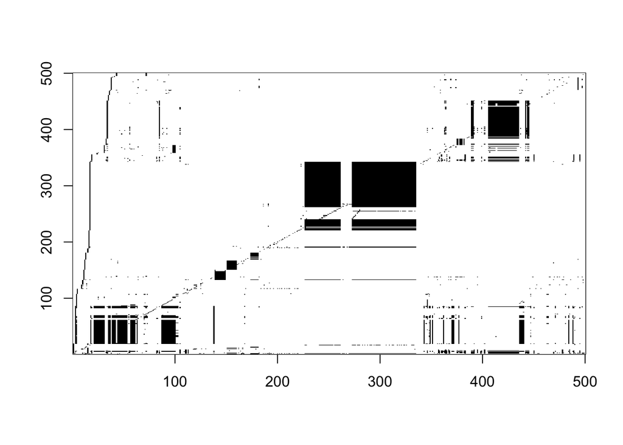

```r
# visualize the connectivity matrix: moderately sparse!
image(1:dim(A)[1], 1:dim(A)[2], A, col = c("#FFFFFF", "#000000"),
      xlab="", ylab="")
```

We see the URL http://www has the largest in-degree. I think it comes from a template many NCSU webpages use; the web crawler I used wrongly recognizes this as a web address. The page http://magazine.amstat.org/blog/category/presidentscorner has the largest out-degree, with 126 links on it.

Some data cleaning is necessary. I decide to delete those web authoring template pages:

```r
rmidx <- c(2, 108, 114, 115, 117, 124, 133, 135, 136,
           169, 221, 336, 337, 340, 386)
U[rmidx]
```

```
##  [1] "http://www"
##  [2] "http://drupal.org)"
##  [3] "http://schema.org/Library"
##  [4] "http://schema.org/PostalAddress"
##  [5] "http:/"
##  [6] "http://www."
##  [7] "http://gmpg.org/xfn/11"
##  [8] "http://brc.ncsu.edu/feed"
##  [9] "http://brc.ncsu.edu/comments/feed"
## [10] "http://ogp.me/ns"
## [11] "http://magazine.amstat.org/feed"
## [12] "http:\\/\\/magazine.amstat.org\\/wp-admin\\/admin-ajax.php"
## [13] "http:\\/\\/magazine.amstat.org\\/wp-content\\/plugins\\/wp-postratings"
## [14] "http://magazine.amstat.org/comments/feed"
## [15] "http://info.ncsu.edu/strategic-planning/comments/feed"
```

```r
Unew <- U[-rmidx]
Anew <- A[-rmidx, -rmidx]
```

We end up with a world of 485 webpages centered around http://www.stat.ncsu.edu and want to rank the pages in this `stat-ncsu` world.

# Q4

We write a function for the PageRank problem using LU, QR, Jacobi, and power methods.

```r
#' PageRank algorithm for computing ranks of pages based on connectivity matrix
#'
#' \code{pagerank} implements the PageRank algorithm using LU, Jacobi, Eigen,
#' and Power methods.
#'
#' @param A an n-by-by connectivity matrix with $a_{ij}=1$ if i links to j
#' @param telep the teleportation parameter with a default value of 0.85
#' @param method the numerical method for PageRank algorithm, default is "lu"
#' @param maxiter the maximum iterations for Jacobi and Power methods
#' @param tolx the tolerance in the l1 norm of solution
#' @param x0 starting point
#' @return the vector of page ranks (normalized to have sum 1)
#' @seealso
pagerank <- function(A, telep = 0.85, method = "lu", maxiter = 1000,
                     tolx = 1e-6, x0 = NULL) {

  # check dimension
  if (!is.matrix(A) || dim(A)[1] != dim(A)[2])
    stop("A must be a square matrix")
  n <- dim(A)[1] # n = number of pages
  if (!is.null(x0) && length(x0) != n)
    stop("starting vector x0 should have same length as dim(A)[1]")

  # load the Matrix package if not yet
  if (!is.element("Matrix", installed.packages()[, 1])) {
    install.packages(Matrix, repos = "http://cran.us.r-project.org")
    }
  library(Matrix)

  # precompute some variables
  # use sparse matrix to speed up computation
  Asp <- Matrix(A, sparse = TRUE)
  outdeg <- rowSums(Asp)
  outdeginv <- ifelse(outdeg > 0, telep / outdeg, 0)
  z <- ifelse(outdeg > 0, 1 - telep, 1) / n
  # G is the R^+ A matrix
  G <- outdeginv * Asp

  # compute page ranks
  if (method == "lu") {

    # prepare the linear system I - P^t
    M <- - t(G + z)
    diag(M) <- diag(M) + 1
    # replace the first equation by the sum-to-1 constraint
    M[1, ] <- 1
    # LU solve with right hand side e_1
    pgrank <- solve(M, c(1, rep(0, n - 1)))

    } else if (method == "qr") {

      # prepare the linear system M = I - P
      M <- - (G + z)
      diag(M) <- diag(M) + 1
      # QR decomposition (with column pivoting) of M
      # last column of Q is in N(I-P^T), which is retrieved by Q e_n
      pgrank <- qr.qy(qr(M), c(rep(0, n - 1), 1))
      pgrank <- abs(pgrank / sum(pgrank))

      } else if (method == "jacobi") {

        # set starting point
        if (is.null(x0)) {
          x = rep(1 / n, n)
          } else {
            x = abs(x0 / sum(x0))
            }
        # obtain diagonal of the linear system
        dg <- 1 - diag(G) - z
        # Jacobi iterations
        for (iter in 1:maxiter) {
          xold <- x
          # this is (I - P^T)x
          x <- x - x %*% G - sum(x * z)
          # this is Jacobi update
          x <- xold -  x / dg
          # re-normalize: not necessary
          # x <- x / sum(x)
          # stopping criterion: change in L1 norm
          if (sum(abs(x - xold)) < tolx)
            break
          }
        if (iter == maxiter) {
          warning(paste("fail to converge in", maxiter, " iterations!"))
          } else {
            print(paste("converged in", iter, "iterations"))
            }
        pgrank <- abs(x / sum(x))

        } else if (method == "eig") {

          # prepare the transition matrix
          P <- G + z
          # eigen-decomposition
          eig.tp <- eigen(t(P), symmetric = FALSE)
          pgrank <- Re(eig.tp$vectors[, which.max(Re(eig.tp$values))])
          # normalize
          pgrank <- abs(pgrank / sum(pgrank))

          } else if (method == "power") {

            # set starting point
            if (is.null(x0)) {
              x = rep(1 / n, n)
              } else {
                x = abs(x0 / sum(x0))
                }
            # Power iterations
            for (iter in 1:maxiter) {
              xold <- x
              # this is Power update
              x <- x %*% G + sum(x * z)
              # re-normalize
              x <- x / sqrt(sum(x^2))
              # stopping criterion: change in L1 norm
              if (sum(abs(x - xold)) < tolx)
                break
              }
            if (iter == maxiter) {
              warning(paste("fail to converge in", maxiter, " iterations!"))
              } else {
                print(paste("converged in", iter, "iterations"))
                }
            # normalize
            pgrank <- x / sum(x)

            } else {
              stop("unknown method option")
              }

  # output
  return(pgrank)

  }
```

Now let’s obtain PageRank for our `stat-ncsu` data. First is the LU decomposition.

```r
library(Matrix)
library(knitr)
timing.lu <- system.time(ncsustatpgrk.lu <- pagerank(Anew, method = 'lu'))
timing.lu
```

```
##    user  system elapsed
##   0.251   0.016   0.296
```

```r
topidx <- order(ncsustatpgrk.lu, decreasing = TRUE)[1:20]
toplist <- cbind(Unew[topidx], ncsustatpgrk.lu[topidx],
                 indeg[topidx], outdeg[topidx])
colnames(toplist) <- c("url", "page rank", "in-deg", "out-deg")
kable(toplist, format = "pandoc", caption = "PageRank by LU",
      align = c("l", "l", "l", "l"), row.names = FALSE)
```

```
##
##
## Table: PageRank by LU
##
## url                                             page rank             in-deg   out-deg
## ----------------------------------------------  --------------------  -------  --------
## http://www.huffingtonpost.com                   0.0340503973716587    9        15
## http://instagram.com/ncstate                    0.0315555712298483    86       0
## http://instagram.com/ncsulibraries              0.0214735020412424    1        4
## http://www.amstat.org                           0.0168451703779813    9        16
## http://ncsu.edu                                 0.014268310547914     1        0
## http://community.amstat.org                     0.0141703792296831    4        105
## http://www.amstat.org/accreditation/index.cfm   0.0141047966212739    2        104
## http://www.statsols.com/amstat                  0.0137331618402885    4        104
## http://www.ncsu.edu                             0.0112519575250086    217      1
## http://www.lib.ncsu.edu                         0.00852768071785348   79       72
## http://mypack.ncsu.edu                          0.00790081002209254   147      9
## http://www.pinterest.com/amstatnews             0.00752060497918699   2        105
## http://www.duke.edu                             0.00722147280715536   2        5
## http://policies.ncsu.edu                        0.00665259487511601   3        56
## http://twitter.com/AmstatNews                   0.00657721149036028   59       103
## http://info.ncsu.edu/strategic-planning         0.00638835348115144   89       1
## http://instagram.com/p/tIS5aGGIzZ               0.00577524630871525   3        1
## http://www.samsi.info                           0.00576030364764922   9        10
## http://instagram.com/p/ss4oRVGI08               0.00559020662992752   3        1
## http://instagram.com/p/r4vsXkmI8J               0.00559020662992752   3        1
```

QR decomposition (suggested by Liuyi Hu):

```r
timing.qr <- system.time(ncsustatpgrk.qr <- pagerank(Anew, method = 'qr'))
timing.qr
```

```
##    user  system elapsed
##   0.108   0.006   0.116
```

```r
topidx <- order(ncsustatpgrk.qr, decreasing = TRUE)[1:20]
toplist <- cbind(Unew[topidx], ncsustatpgrk.lu[topidx],
                 indeg[topidx], outdeg[topidx])
colnames(toplist) <- c("url", "page rank", "in-deg", "out-deg")
kable(toplist, format = "pandoc", caption = "PageRank by QR",
      align = c("l", "l", "l", "l"), row.names = FALSE)
```

```
##
##
## Table: PageRank by QR
##
## url                                             page rank             in-deg   out-deg
## ----------------------------------------------  --------------------  -------  --------
## http://www.huffingtonpost.com                   0.0340503973716587    9        15
## http://instagram.com/ncstate                    0.0315555712298483    86       0
## http://instagram.com/ncsulibraries              0.0214735020412424    1        4
## http://www.amstat.org                           0.0168451703779813    9        16
## http://ncsu.edu                                 0.014268310547914     1        0
## http://community.amstat.org                     0.0141703792296831    4        105
## http://www.amstat.org/accreditation/index.cfm   0.0141047966212739    2        104
## http://www.statsols.com/amstat                  0.0137331618402885    4        104
## http://www.ncsu.edu                             0.0112519575250086    217      1
## http://www.lib.ncsu.edu                         0.00852768071785348   79       72
## http://mypack.ncsu.edu                          0.00790081002209254   147      9
## http://www.pinterest.com/amstatnews             0.00752060497918699   2        105
## http://www.duke.edu                             0.00722147280715536   2        5
## http://policies.ncsu.edu                        0.00665259487511601   3        56
## http://twitter.com/AmstatNews                   0.00657721149036028   59       103
## http://info.ncsu.edu/strategic-planning         0.00638835348115144   89       1
## http://instagram.com/p/tIS5aGGIzZ               0.00577524630871525   3        1
## http://www.samsi.info                           0.00576030364764922   9        10
## http://instagram.com/p/scw-FOmI70               0.00559020662992751   3        1
## http://instagram.com/p/tBLeaOmIyC               0.00559020662992751   5        1
```

Jacobi iterative method:

```r
timing.jacobi <-
  system.time(ncsustatpgrk.jacobi <- pagerank(Anew, method = "jacobi"))
```

```
## [1] "converged in 34 iterations"
```

```r
timing.jacobi
```

```
##    user  system elapsed
##   0.149   0.012   0.162
```

```r
topidx <- order(ncsustatpgrk.jacobi, decreasing = TRUE)[1:20]
toplist <- cbind(Unew[topidx], ncsustatpgrk.jacobi[topidx],
                 indeg[topidx], outdeg[topidx])
colnames(toplist) <- c("url", "page rank", "in-deg", "out-deg")
kable(toplist, format = "pandoc", caption = "PageRank by Jacobi",
      align = c("l", "l", "l", "l"), row.names = FALSE)
```

```
##
##
## Table: PageRank by Jacobi
##
## url                                             page rank             in-deg   out-deg
## ----------------------------------------------  --------------------  -------  --------
## http://www.huffingtonpost.com                   0.0340504128832321    9        15
## http://instagram.com/ncstate                    0.0315556419947655    86       0
## http://instagram.com/ncsulibraries              0.0214735630799507    1        4
## http://www.amstat.org                           0.0168449884132837    9        16
## http://ncsu.edu                                 0.014268341772725     1        0
## http://community.amstat.org                     0.0141702136532171    4        105
## http://www.amstat.org/accreditation/index.cfm   0.0141046020049534    2        104
## http://www.statsols.com/amstat                  0.0137331442797079    4        104
## http://www.ncsu.edu                             0.0112519789885463    217      1
## http://www.lib.ncsu.edu                         0.00852770144758837   79       72
## http://mypack.ncsu.edu                          0.00790082772137129   147      9
## http://www.pinterest.com/amstatnews             0.0075205375737153    2        105
## http://www.duke.edu                             0.0072214772591724    2        5
## http://policies.ncsu.edu                        0.00665260998976388   3        56
## http://twitter.com/AmstatNews                   0.00657714772556783   59       103
## http://info.ncsu.edu/strategic-planning         0.00638836658111303   89       1
## http://instagram.com/p/tIS5aGGIzZ               0.00577525313591567   3        1
## http://www.samsi.info                           0.0057603083986416    9        10
## http://instagram.com/p/tSrI4GmI4X               0.00559021323238116   3        10
## http://instagram.com/p/tBLeaOmIyC               0.00559021323238116   5        1
```

Eigen-decomposition method:

```r
timing.eig <-
  system.time(ncsustatpgrk.eig <- pagerank(Anew, method = "eig"))
timing.eig
```

```
##    user  system elapsed
##   0.646   0.009   0.664
```

```r
topidx <- order(ncsustatpgrk.eig, decreasing = TRUE)[1:20]
toplist <- cbind(Unew[topidx], ncsustatpgrk.eig[topidx],
                 indeg[topidx], outdeg[topidx])
colnames(toplist) <- c("url", "page rank", "in-deg", "out-deg")
kable(toplist, format = "pandoc", caption = "PageRank by Eigen-decomposition",
      align = c("l", "l", "l", "l"), row.names = FALSE)
```

```
##
##
## Table: PageRank by Eigen-decomposition
##
## url                                             page rank             in-deg   out-deg
## ----------------------------------------------  --------------------  -------  --------
## http://www.huffingtonpost.com                   0.0340503973716569    9        15
## http://instagram.com/ncstate                    0.0315555712298471    86       0
## http://instagram.com/ncsulibraries              0.0214735020412419    1        4
## http://www.amstat.org                           0.0168451703779808    9        16
## http://ncsu.edu                                 0.0142683105479142    1        0
## http://community.amstat.org                     0.0141703792296826    4        105
## http://www.amstat.org/accreditation/index.cfm   0.0141047966212734    2        104
## http://www.statsols.com/amstat                  0.0137331618402877    4        104
## http://www.ncsu.edu                             0.0112519575250087    217      1
## http://www.lib.ncsu.edu                         0.00852768071785374   79       72
## http://mypack.ncsu.edu                          0.00790081002209317   147      9
## http://www.pinterest.com/amstatnews             0.00752060497918673   2        105
## http://www.duke.edu                             0.0072214728071556    2        5
## http://policies.ncsu.edu                        0.00665259487511599   3        56
## http://twitter.com/AmstatNews                   0.00657721149036007   59       103
## http://info.ncsu.edu/strategic-planning         0.00638835348115148   89       1
## http://instagram.com/p/tIS5aGGIzZ               0.00577524630871501   3        1
## http://www.samsi.info                           0.00576030364765002   9        10
## http://instagram.com/p/tBLeaOmIyC               0.00559020662992727   5        1
## http://instagram.com/p/tSrI4GmI4X               0.00559020662992727   3        10
```

Power method:

```r
timing.power <-
  system.time(ncsustatpgrk.power <- pagerank(Anew, method = "power"))
```

```
## [1] "converged in 74 iterations"
```

```r
timing.power
```

```
##    user  system elapsed
##   0.158   0.007   0.166
```

```r
topidx <- order(ncsustatpgrk.power, decreasing = TRUE)[1:20]
toplist <- cbind(Unew[topidx], ncsustatpgrk.power[topidx],
                 indeg[topidx], outdeg[topidx])
colnames(toplist) <- c("url", "page rank", "in-deg", "out-deg")
kable(toplist, format = "pandoc", caption = "PageRank by Power Method",
      align = c("l", "l", "l", "l"), row.names = FALSE)
```

```
##
##
## Table: PageRank by Power Method
##
## url                                             page rank             in-deg   out-deg
## ----------------------------------------------  --------------------  -------  --------
## http://www.huffingtonpost.com                   0.0340503814329927    9        15
## http://instagram.com/ncstate                    0.0315555494575349    86       0
## http://instagram.com/ncsulibraries              0.0214734850466446    1        4
## http://www.amstat.org                           0.01684517510216      9        16
## http://ncsu.edu                                 0.0142683123080763    1        0
## http://community.amstat.org                     0.0141703832116967    4        105
## http://www.amstat.org/accreditation/index.cfm   0.0141048009666154    2        104
## http://www.statsols.com/amstat                  0.0137331521586957    4        104
## http://www.ncsu.edu                             0.0112519588468101    217      1
## http://www.lib.ncsu.edu                         0.00852768184881325   79       72
## http://mypack.ncsu.edu                          0.00790081099819301   147      9
## http://www.pinterest.com/amstatnews             0.00752060702238651   2        105
## http://www.duke.edu                             0.00722146934537146   2        5
## http://policies.ncsu.edu                        0.00665259570501505   3        56
## http://twitter.com/AmstatNews                   0.00657721325535698   59       103
## http://info.ncsu.edu/strategic-planning         0.00638835423946562   89       1
## http://instagram.com/p/tIS5aGGIzZ               0.0057752434212119    3        1
## http://www.samsi.info                           0.0057603042504621    9        10
## http://instagram.com/p/tSrI4GmI4X               0.00559020384145876   3        10
## http://instagram.com/p/tBLeaOmIyC               0.00559020384145876   5        1
```

| Method | Run time (seconds) |
| --- | --- |
| `LU` | 0.296 |
| `qr` | 0.116 |
| `Eigen` | 0.664 |
| `Jacobi` | 0.162 |
| `Power` | 0.166 |

Even in this small example, we see some advantages of the (naive) iterative solvers such as Jacobi and power methods. More advanced iterative solvers (conjugate gradient and variants) can further cut down the number of iterations and solve huge linear systems such as the real scale Google PageRank application. Iterative methods also pocesss the advantages of warm start and allowing looser convergence criterion (do you really want a super-accurate solution?).

Clean up workspace

```r
## clean and close
#rm(list = ls())
```

# Some more questions to ponder

- Who is the most influential statisitican? Which is the most influential statistical paper? We may answer these types of questions using PageRank algorithm. How to take into account time effects (new papers can only cite older papers)?
- What is the optimal strategy to to put links on a webpage to maximize its rank?